# Preprocessing

# Preprocessing

1. Libraries and data upload
2. Raw data analysis
3. Data preparation and summaries
4. Log transformation
5. Stationarity
6. ACF and PACF
7. First Difference (7.1 Stationarity; 7.2 ACF and PACF)
8. Training and Test Sets

## 1. Libraries and data upload

```r
# 1. Libraries and data upload
library(ggplot2)
library(urca)
library(tseries)
data <- read.csv("data/UMCSENT.csv")
```

## 2. Raw data analysis

```r
# 2. Raw data analysis
str(data) # observation_date chr; UMCSENT num
```

```
## 'data.frame':    875 obs. of  2 variables:
##  $ observation_date: chr  "1952-11-01" "1952-12-01" "1953-01-01" "1953-02-01" ...
##  $ UMCSENT         : num  86.2 NA NA 90.7 NA NA NA NA NA 80.8 ...
```

```r
data$observation_date <- as.Date(data$observation_date, format = "%Y-%m-%d") # observation_date conversion to Date
str(data)
```

```
## 'data.frame':    875 obs. of  2 variables:
##  $ observation_date: Date, format: "1952-11-01" "1952-12-01" ...
##  $ UMCSENT         : num  86.2 NA NA 90.7 NA NA NA NA NA 80.8 ...
```

```r
sum(is.na(data$UMCSENT)) # 210 missing values
```

```
## [1] 210
```

```r
mean(is.na(data$UMCSENT)) # 24% of missing values
```

```
## [1] 0.24
```

```r
nrow(data) # 875
```

```
## [1] 875
```

```r
range(data$observation_date) # "1952-11-01" "2025-09-01"
```

```
## [1] "1952-11-01" "2025-09-01"
```

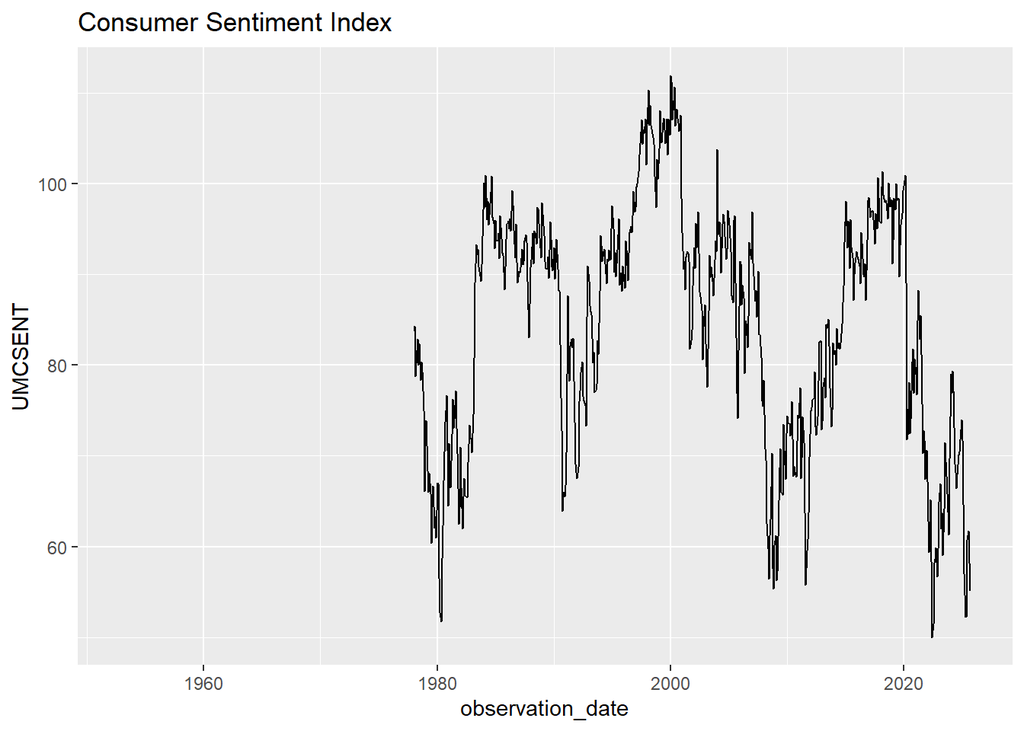

```r
ggplot(data, aes(x = observation_date, y = UMCSENT)) +
  geom_line() +
  labs(title = 'Consumer Sentiment Index')
```

## 3. Data preparation and summaries

```r
# 3. Data preparation and summaries

# data from 1978
data_filtered <- subset(data, observation_date >= "1978-01-01")
nrow(data_filtered) # 573
```

```
## [1] 573
```

```r
range(data_filtered$observation_date) # "1978-01-01" "2025-09-01"
```

```
## [1] "1978-01-01" "2025-09-01"
```

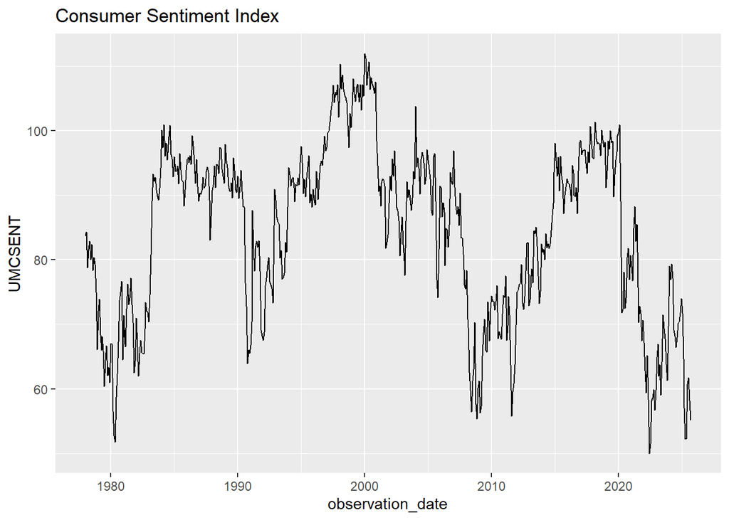

```r
ggplot(data_filtered, aes(x = observation_date, y = UMCSENT)) +
  geom_line() +
  labs(title = 'Consumer Sentiment Index')
```

```r
# statistics
summary(data_filtered$UMCSENT)
```

```
##    Min. 1st Qu.  Median    Mean 3rd Qu.    Max.
##    50.0    73.5    88.2    84.3    94.4   112.0
```

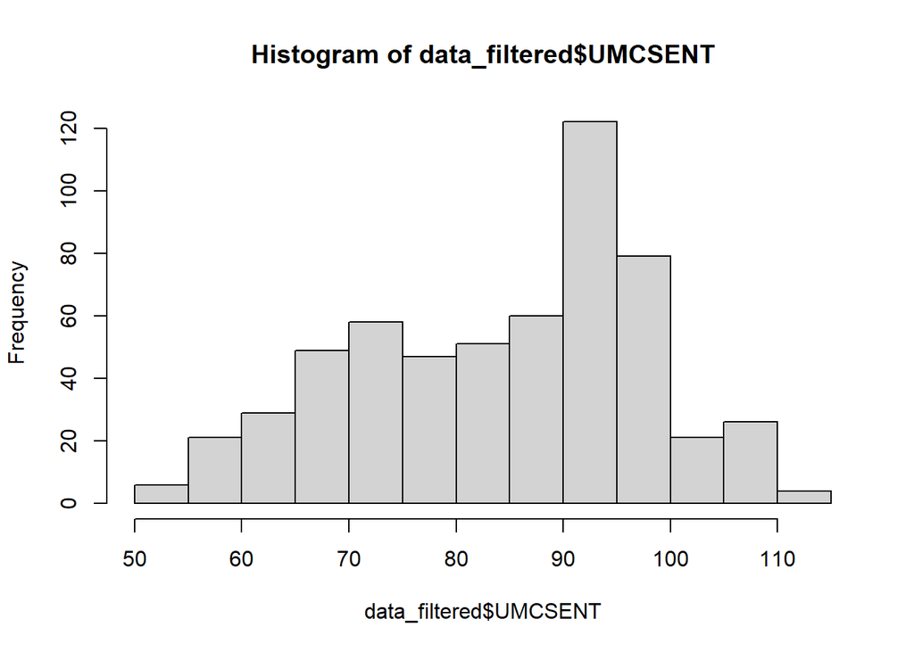

```r
# check outliers
hist(data_filtered$UMCSENT, breaks = 20) # not normally distributed
```

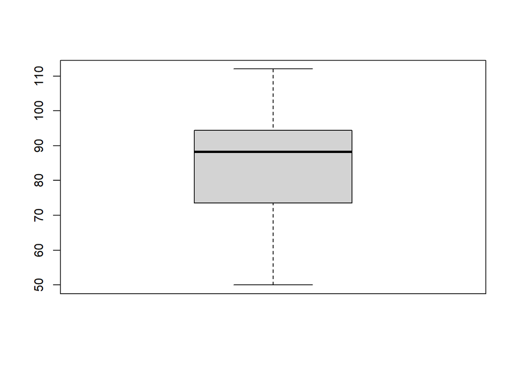

```r
boxplot(data_filtered$UMCSENT) # values are distributed in the 70-90 range with 88.2 as the median
```

## 4. Log transformation

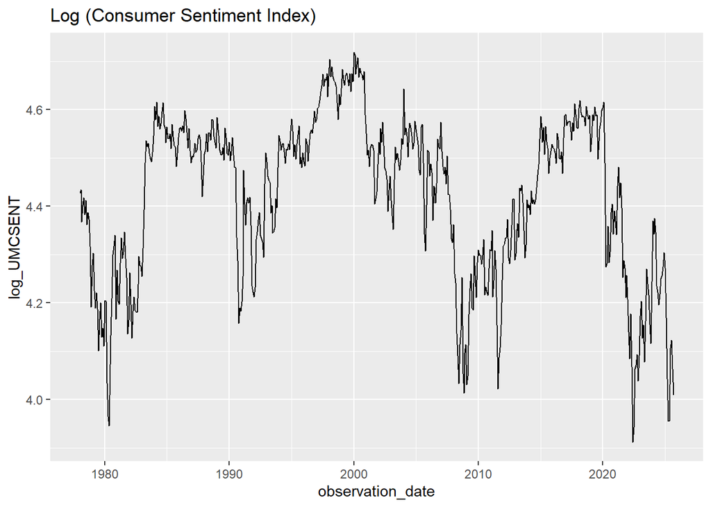

```r
# Log transformation for positive time series
data_filtered$log_UMCSENT <- log(data_filtered$UMCSENT)

ggplot(data_filtered, aes(x = observation_date, y = log_UMCSENT)) +
  geom_line() +
  labs(title = 'Log (Consumer Sentiment Index)')
```

## 5. Stationarity

```r
# Stationarity test
# ADF -> stationary
summary(ur.df(data_filtered$log_UMCSENT, type = "drift"))
```

```
##
## ###############################################
## # Augmented Dickey-Fuller Test Unit Root Test #
## ###############################################
##
## Test regression drift
##
##
## Call:
## lm(formula = z.diff ~ z.lag.1 + 1 + z.diff.lag)
##
## Residuals:
##       Min        1Q    Median        3Q       Max
## -0.212379 -0.024285  0.003248  0.031970  0.209817
##
## Coefficients:
##             Estimate Std. Error t value Pr(>|t|)
## (Intercept)  0.20364    0.05802   3.510 0.000484 ***
## z.lag.1     -0.04622    0.01311  -3.525 0.000458 ***
## z.diff.lag   0.05517    0.04213   1.310 0.190842
## ---
## Signif. codes:  0 '***' 0.001 '**' 0.01 '*' 0.05 '.' 0.1 ' ' 1
##
## Residual standard error: 0.05216 on 568 degrees of freedom
## Multiple R-squared:  0.0223, Adjusted R-squared:  0.01885
## F-statistic: 6.476 on 2 and 568 DF,  p-value: 0.001656
##
##
## Value of test-statistic is: -3.5248 6.2673
##
## Critical values for test statistics:
##       1pct  5pct 10pct
## tau2 -3.43 -2.86 -2.57
## phi1  6.43  4.59  3.78
```

```r
# KPSS -> non-stationary
kpss.test(data_filtered$log_UMCSENT)
```

```
##
##  KPSS Test for Level Stationarity
##
## data:  data_filtered$log_UMCSENT
## KPSS Level = 0.75876, Truncation lag parameter = 6, p-value = 0.01
```

### 1. Augmented Dickey-Fuller (ADF) Test

This test checks for the presence of a unit root (non-stationarity).

- $H_0$ (Null Hypothesis): The series is **not stationary** (it has a unit root).
- $H_1$ (Alternative Hypothesis): The series **is stationary**.
- **Result:** The test statistic value ($t$) is **-3.5248**. This is more negative than the 1% critical value (-3.43).
- **Conclusion:** **Reject** $H_0$. According to this test, the series is considered **stationary** (with a 99% confidence level).

### 2. KPSS Test

This test works with the opposite hypotheses compared to the ADF test.

- $H_0$ (Null Hypothesis): The series **is stationary** (level stationarity).
- $H_1$ (Alternative Hypothesis): The series is **not stationary**.
- **Result:** The *p-value* is **0.01** (indicating it is smaller than the printed value).
- **Conclusion:** Since the p-value is lower than the standard threshold of 0.05 (5%), **reject** $H_0$. According to this test, the series is **not stationary**.

## 6. Autocorrelation

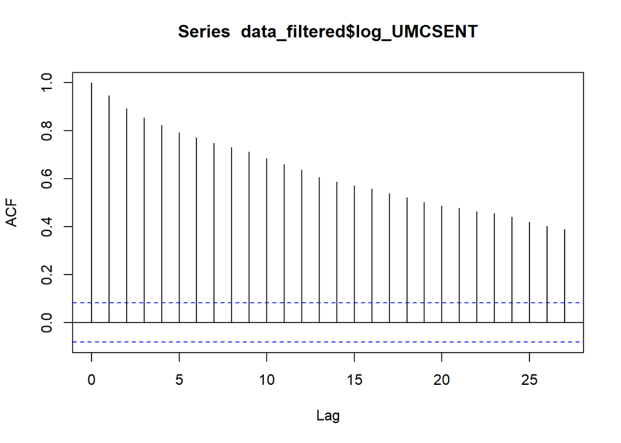

```r
# ACF and PACF
acf(data_filtered$log_UMCSENT)
```

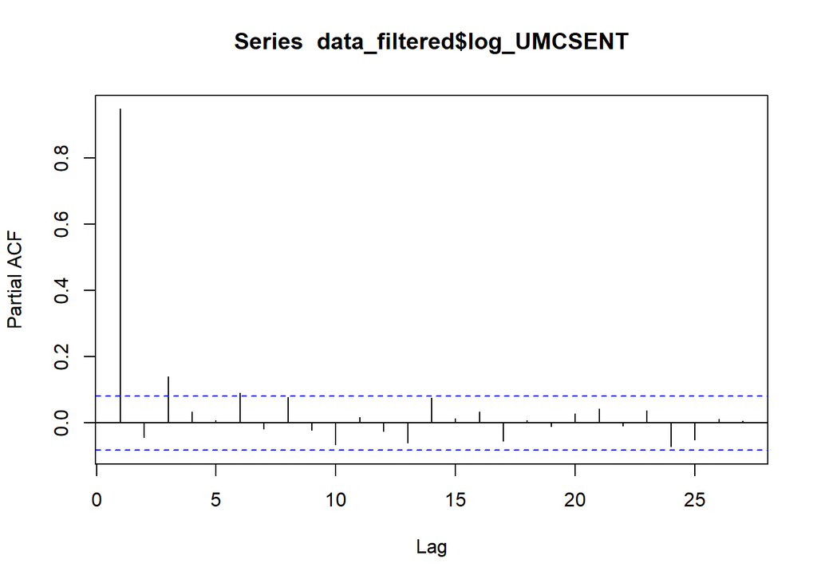

```r
pacf(data_filtered$log_UMCSENT)
```